# Bayesian analysis of the packaged example data

`TruncComp2` now includes an experimental Bayesian interface, `trunc_comp_bayes()`, for the no-covariate two-group comparison. This vignette applies that interface to the packaged example data set and shows how to move from the raw atom-plus-continuous outcome to posterior summaries for the atom probability contrast, the non-atom mean contrast, and the combined-outcome contrast. The packaged example uses the default `continuous_support = "real_line"` pathway, but the same interface also supports `continuous_support = "positive_real"` when all non-atom outcomes are strictly positive, and experimental bounded models through `continuous_support = "bounded_continuous"` or `continuous_support = "bounded_score"`. The bounded models use Beta mixture kernels by default and can instead use logit-normal mixture kernels with `bounded_kernel = "logit_normal"`.

The example data set is intentionally small, but the Stan fit below uses `4` chains with `500` warmup iterations and `1000` post-warmup iterations per chain so the posterior summaries are based on a more stable run than a minimal smoke-test configuration. For an applied analysis, you should still inspect the sampler diagnostics carefully and increase the sampling effort further if they remain unsatisfactory.

## Load the example data

```r
library(TruncComp2)

data("trunc_comp_example", package = "TruncComp2")
example_data <- transform(
  trunc_comp_example,
  A = as.integer(Y != 0)
)

head(example_data, 10)
```

```
#>    R        Y A
#> 1  0 0.000000 0
#> 2  0 5.444875 1
#> 3  0 0.000000 0
#> 4  0 0.000000 0
#> 5  0 0.000000 0
#> 6  0 0.000000 0
#> 7  0 5.206920 1
#> 8  0 3.830355 1
#> 9  0 5.555783 1
#> 10 0 0.000000 0
```

The packaged example uses `0` as the atom, so `A = 0` marks the undefined or unobserved outcome and `A = 1` marks rows where the continuous outcome is observed away from the atom.

Before fitting the Bayesian model, it is helpful to inspect the two groups on the three scales that matter most:

- the atom probability
- the mean among the non-atom outcomes
- the mean on the original combined-outcome scale

```r
arm_summary <- do.call(
  rbind,
  lapply(split(example_data, example_data$R), function(d) {
    data.frame(
      n = nrow(d),
      atom_probability = mean(d$A == 0L),
      observed_probability = mean(d$A == 1L),
      mean_non_atom = mean(d$Y[d$A == 1L]),
      mean_combined = mean(d$Y),
      row.names = NULL
    )
  })
)

arm_summary$arm <- c("control", "treatment")
arm_summary <- arm_summary[, c("arm", "n", "atom_probability",
                               "observed_probability", "mean_non_atom",
                               "mean_combined")]
arm_summary
```

```
#>         arm  n atom_probability observed_probability mean_non_atom
#> 0   control 25             0.40                 0.60      4.992855
#> 1 treatment 25             0.56                 0.44      6.849363
#>   mean_combined
#> 0      2.995713
#> 1      3.013720
```

This quick table already shows why the two-part decomposition is useful: one group can look better on the non-atom mean while also having a worse atom probability.

## Fit the Bayesian two-part model

The Bayesian interface mirrors the unadjusted formula interface used elsewhere in the package. In the current implementation:

- the atom is modeled separately in each arm
- the non-atom outcomes are modeled with arm-specific truncated stick-breaking mixtures chosen by `continuous_support`
- bounded continuous and bounded score supports can use either Beta kernels or logit-normal kernels
- covariate adjustment is not yet supported

```r
fit_bayes <- trunc_comp_bayes(
  Y ~ R,
  atom = 0,
  data = example_data,
  chains = 4,
  iter_warmup = 500,
  iter_sampling = 1000,
  mixture_components = 6,
  seed = 20260418,
  refresh = 0
)

fit_bayes
```

```
#> <trunc_comp_bayes_fit>
#> Call:
#> trunc_comp_bayes.formula(formula = Y ~ R, atom = 0, data = example_data,
#>     mixture_components = 6, chains = 4, iter_warmup = 500, iter_sampling = 1000,
#>     seed = 20260418, refresh = 0)
#> Method: Experimental Bayesian two-part Dirichlet process mixture model
#> Experimental: TRUE
#> Continuous support: real_line
#> Success: TRUE
#>       delta    mu_delta  delta_atom alpha_delta
#> -0.02915311  1.68559870  0.15232804  0.53595150
#>
#> Use summary() for posterior intervals and diagnostics.
```

The printed fit shows the four main treatment-effect summaries:

- `delta_atom`: difference in atom probability
- `mu_delta`: difference in means among non-atom outcomes
- `alpha_delta`: odds ratio of being observed away from the atom
- `delta`: combined-outcome contrast

The stored posterior summary table is often the most convenient compact view:

```r
fit_bayes$summary_table
```

```
#>               parameter    estimate   conf.low conf.high posterior_prob
#> delta_atom   delta_atom  0.15232804 -0.1264022 0.4093216         0.8455
#> mu_delta       mu_delta  1.68559870  0.5895201 2.6130027         0.9965
#> alpha_delta alpha_delta  0.53595150  0.1708097 1.6775971         0.1545
#> delta             delta -0.02915311 -1.6319134 1.7228790         0.4845
```

These reported point estimates are posterior medians. The `posterior_prob` column is the posterior probability that the corresponding contrast exceeds its null value, which is `0` for `delta_atom`, `mu_delta`, and `delta`, and `1` for `alpha_delta`.

The model also stores arm-specific posterior summaries:

```r
fit_bayes$arm_table
```

```
#>        parameter  estimate  conf.low conf.high
#> rho_0      rho_0 0.4032790 0.2297730 0.6000624
#> rho_1      rho_1 0.5588381 0.3654237 0.7380004
#> pi_0        pi_0 0.5967210 0.3999376 0.7702270
#> pi_1        pi_1 0.4411619 0.2619996 0.6345763
#> mu_0_c    mu_0_c 5.0272132 4.5152316 5.6245783
#> mu_1_c    mu_1_c 6.7375970 5.8148383 7.4469429
```

Here `rho_0` and `rho_1` are the arm-specific atom probabilities, `pi_0` and `pi_1` are the arm-specific probabilities of being observed away from the atom, and `mu_0_c` and `mu_1_c` are the means among the non-atom outcomes.

## Posterior outcome densities

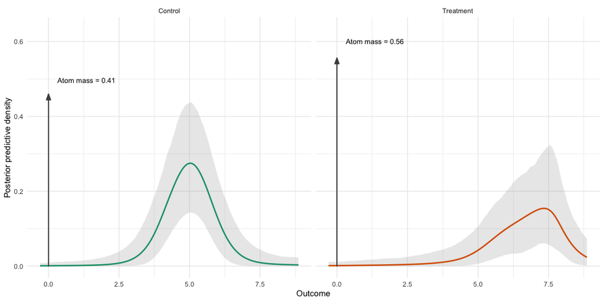

```r
observed_range <- range(example_data$Y[example_data$A == 1])
density_x <- seq(
  min(fit_bayes$atom, observed_range[1]) - 0.3,
  observed_range[2] + 0.8,
  length.out = 300
)

posterior_density_plot(fit_bayes, x = density_x)
```

## Posterior predictive checks

The fit object also supports posterior predictive checks for both parts of the Bayesian model. The atom PPC compares the fitted Bernoulli atom model with the observed atom indicators, while the continuous PPC compares replicated non-atom draws from the fitted mixture model with the observed non-atom outcomes. The package also reports discrepancy-based posterior predictive p-values for these two checks. These are posterior predictive model-checking summaries rather than frequentist hypothesis-test p-values.

```r
posterior_predictive_pvalues(fit_bayes)
```

```
#>             component p_value                                    statistic
#> atom             atom   0.535 Maximum armwise absolute atom-rate deviation
#> continuous continuous   0.425               Maximum armwise KS discrepancy
#>                             scale ndraws mean_observed_discrepancy
#> atom       Indicator for Y = atom    200                 0.1069522
#> continuous                Outcome    200                 0.2800245
#>            mean_replicated_discrepancy
#> atom                         0.1149598
#> continuous                   0.2680115
```

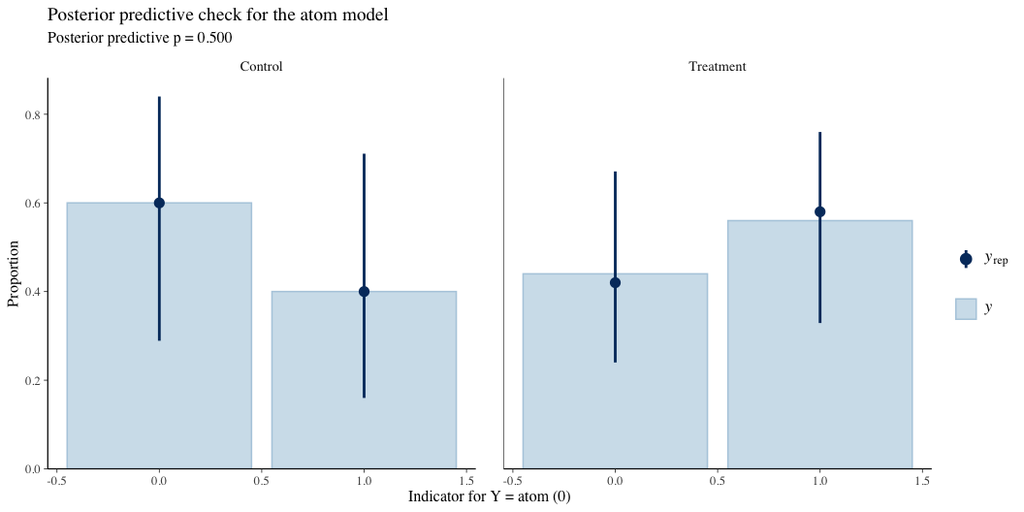

```r
ppc_plots <- posterior_predictive_check(fit_bayes, seed = 1)
print(ppc_plots$atom)
```

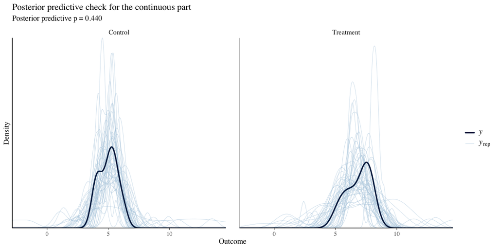

```r
print(ppc_plots$continuous)
```

## Credible intervals and custom posterior summaries

You can extract equal-tail credible intervals for the main contrasts with `confint()`:

```r
confint(fit_bayes, parameter = c("delta_atom", "mu_delta", "delta"))
```

```
#>                 2.5 %    97.5 %
#> delta_atom -0.1264022 0.4093216
#> mu_delta    0.5895201 2.6130027
#> delta      -1.6319134 1.7228790
```

The full posterior draws are also retained in `fit_bayes$draws`, so it is easy to compute custom posterior summaries. For example, if smaller atom probability is preferable, then a treatment benefit on the atom component corresponds to `delta_atom < 0` rather than `delta_atom > 0`.

```r
posterior_probabilities <- c(
  `Pr(delta > 0)` = mean(fit_bayes$draws$delta > 0),
  `Pr(mu_delta > 0)` = mean(fit_bayes$draws$mu_delta > 0),
  `Pr(delta_atom < 0)` = mean(fit_bayes$draws$delta_atom < 0)
)

posterior_probabilities
```

```
#>      Pr(delta > 0)   Pr(mu_delta > 0) Pr(delta_atom < 0)
#>             0.4845             0.9965             0.1545
```

This is one of the main advantages of the Bayesian fit object: the package returns the posterior draws needed for follow-up summaries rather than only a single test statistic or p-value.

## Diagnostics and practical tuning

The fit object stores a compact diagnostic summary:

```r
data.frame(
  divergences = fit_bayes$diagnostics$divergences,
  max_rhat = fit_bayes$diagnostics$max_rhat,
  min_bulk_ess = fit_bayes$diagnostics$min_bulk_ess,
  min_tail_ess = fit_bayes$diagnostics$min_tail_ess,
  core_ok = fit_bayes$diagnostics$core_ok,
  truncation_ok = fit_bayes$diagnostics$truncation_ok,
  diagnostic_ok = fit_bayes$diagnostics$diagnostic_ok
)
```

```
#>   divergences max_rhat min_bulk_ess min_tail_ess core_ok truncation_ok
#> 1          50 1.001995     2861.323     3115.904   FALSE         FALSE
#>   diagnostic_ok
#> 1         FALSE
```

For truncated stick-breaking mixtures, `truncation_ok` is based on ordinary sampler diagnostics for the concentration parameters and the final retained stick weights.

Because this vignette still uses a small packaged example data set, these diagnostics should be interpreted as an illustration of the workflow rather than as definitive evidence that the model is well calibrated for every application. In a real analysis, a good next step is to rerun the model with additional sampling effort if needed, then inspect `summary(fit_bayes)` and `fit_bayes$diagnostics` again.

The same pattern scales directly to user data with the same structure:

1. code the atom explicitly
2. fit `trunc_comp_bayes(Y ~ R, atom = ...)`
3. inspect `summary_table`, `arm_table`, and diagnostics
4. compute any study-specific posterior probabilities from `fit$draws`

## Positive-support continuous outcomes

If the non-atom outcomes are constrained to the positive real line, set `continuous_support = "positive_real"`. That switches the continuous component from a Gaussian mixture to a Gamma mixture while keeping the same atom model and the same posterior estimands.

```r
positive_example <- simulate_truncated_data(
  20,
  f0 = function(n) stats::rgamma(n, shape = 4, rate = 2.5),
  f1 = function(n) stats::rgamma(n, shape = 5, rate = 2.2),
  pi0 = 0.7,
  pi1 = 0.6,
  atom = 0
)

fit_bayes_positive <- trunc_comp_bayes(
  Y ~ R,
  atom = 0,
  data = positive_example,
  continuous_support = "positive_real",
  chains = 4,
  iter_warmup = 500,
  iter_sampling = 1000,
  mixture_components = 6,
  seed = 20260419,
  refresh = 0
)

coef(fit_bayes_positive)
```

```
#>    mu_delta  delta_atom alpha_delta       delta
#> 0.619273536 0.002120571 0.990535470 0.402143814
```

The same density-plot helper works for the positive-support model. In that case the posterior predictive density is built from the fitted Gamma mixture instead of the real-line Gaussian mixture.

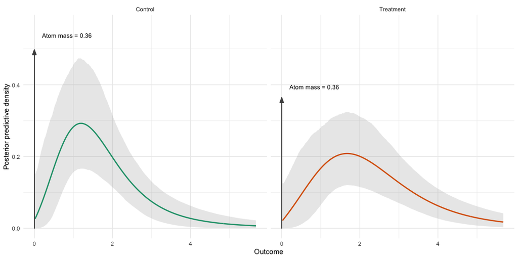

```r
positive_observed_range <- range(positive_example$Y[positive_example$A == 1])
positive_density_x <- seq(
  0,
  positive_observed_range[2] + 1,
  length.out = 300
)

posterior_density_plot(fit_bayes_positive, x = positive_density_x)
```

Posterior predictive checks are also available for the positive-support fit. As before, the atom PPC checks the Bernoulli atom model, while the continuous PPC compares replicated non-atom draws from the fitted Gamma mixture with the observed positive outcomes. For the positive-support fit, the continuous PPC is shown on the `log(Y)` scale so the density overlay is not distorted by the boundary at zero, and the corresponding continuous posterior predictive p-value is computed on that same `log(Y)` scale.

```r
posterior_predictive_pvalues(fit_bayes_positive)
```

```
#>             component p_value                                    statistic
#> atom             atom   0.565 Maximum armwise absolute atom-rate deviation
#> continuous continuous   0.315               Maximum armwise KS discrepancy
#>                             scale ndraws mean_observed_discrepancy
#> atom       Indicator for Y = atom    200                 0.1147928
#> continuous           log(Outcome)    200                 0.3047022
#>            mean_replicated_discrepancy
#> atom                         0.1160629
#> continuous                   0.2648601
```

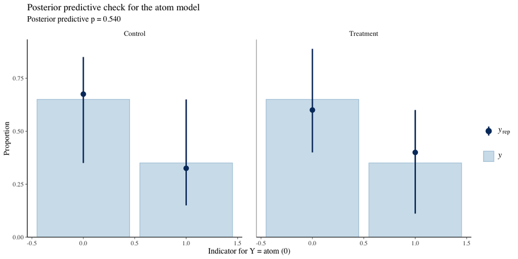

```r
ppc_plots_positive <- posterior_predictive_check(fit_bayes_positive, seed = 1)
print(ppc_plots_positive$atom)
```

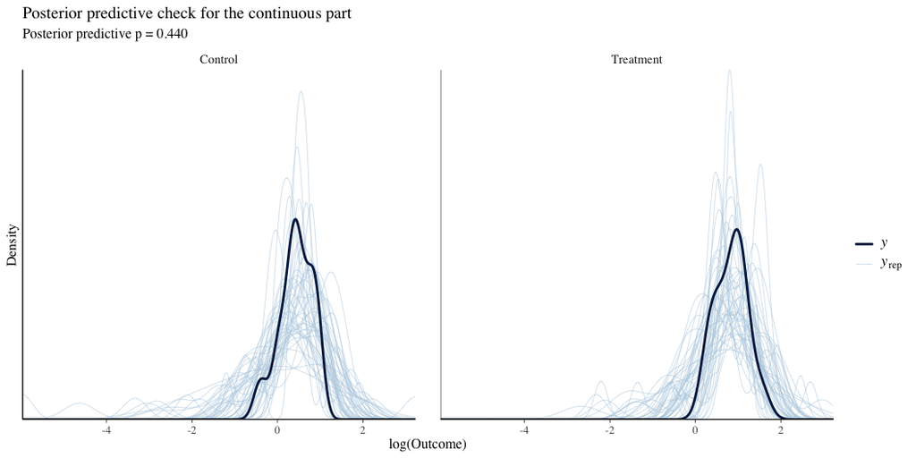

```r
print(ppc_plots_positive$continuous)
```

The posterior draws for the positive-support fit can be summarized in the same way as for the real-line example:

```r
posterior_probabilities_positive <- c(
  `Pr(delta > 0)` = mean(fit_bayes_positive$draws$delta > 0),
  `Pr(mu_delta > 0)` = mean(fit_bayes_positive$draws$mu_delta > 0),
  `Pr(delta_atom < 0)` = mean(fit_bayes_positive$draws$delta_atom < 0)
)

posterior_probabilities_positive
```

```
#>      Pr(delta > 0)   Pr(mu_delta > 0) Pr(delta_atom < 0)
#>            0.83125            0.92150            0.49425
```

## Bounded Outcomes

Two experimental bounded models are also available. Use `continuous_support = "bounded_continuous"` for genuinely continuous or finely measured bounded outcomes with non-atom values strictly inside the supplied range. Use `continuous_support = "bounded_score"` for integer or grid-valued clinical scores; posterior predictive non-atom replications are then sampled on the same reported score support as the observed data.

The bounded models keep support and kernel separate. The default `bounded_kernel = "beta"` uses the original bounded Beta mixture. Setting `bounded_kernel = "logit_normal"` uses ordered component locations on the logit scale with logit-normal kernels. For bounded-score outcomes, the heaping grids describe possible reporting resolutions. For example, `heaping_grids = c(1, 5, 10)` means the reported score may arise from exact integer reporting, rounding to a multiple of five, or rounding to a multiple of ten; the heaping weights are estimated from the data.

```r
fit_bayes_score <- trunc_comp_bayes(
  Y ~ R,
  atom = -1,
  data = ist3,
  continuous_support = "bounded_score",
  bounded_kernel = "logit_normal",
  score_min = 0,
  score_max = 100,
  score_step = 1,
  heaping_grids = c(1, 5, 10),
  heaping = "shared",
  mixture_components = 2,
  chains = 4,
  iter_warmup = 300,
  iter_sampling = 300,
  control = list(adapt_delta = 0.99, max_treedepth = 12),
  prior = list(
    rho_alpha = 1,
    rho_beta = 1,
    alpha_shape = 4,
    alpha_rate = 4,
    mu_logit_mean = 0,
    mu_logit_sd = 2,
    sigma_logit_meanlog = log(1.2),
    sigma_logit_sdlog = 0.5,
    eta_prior = c(2, 2, 2)
  ),
  refresh = 0
)

fit_bayes_score$diagnostics[c(
  "divergences", "max_rhat", "min_bulk_ess", "min_tail_ess",
  "core_ok", "truncation_ok", "diagnostic_ok"
)]

posterior_predictive_check(fit_bayes_score, type = "continuous")
```

[output not shown]